# Final Exam - Review Excercises

STA 235

05/05/2021

# I want to ride my bicycle…

We are going to use the example we saw in class, and play around with this dataset to answer two main questions:

1. How can we predict daily demand? (in the short term)
2. How can we incentivize the use of bike share?

## Prediction

We will be using data from DC. This is the data we have:

```r
library(tidyverse)
library(ggplot2)

bikedc <- read.csv("https://raw.githubusercontent.com/maibennett/sta235/main/exampleSite/content/Classes/Week14/2_Wrapup/data/bikesharedc.csv")

bikedc <- bikedc %>% mutate(season = factor(season),
                            weather = factor(weather),
                            date = as.Date(datetime))

head(bikedc)
```

```
##              datetime season holiday workingday weather temp  atemp humidity
## 1 2011-01-01 00:00:00      1       0          0       1 9.84 14.395       81
## 2 2011-01-01 01:00:00      1       0          0       1 9.02 13.635       80
## 3 2011-01-01 02:00:00      1       0          0       1 9.02 13.635       80
## 4 2011-01-01 03:00:00      1       0          0       1 9.84 14.395       75
## 5 2011-01-01 04:00:00      1       0          0       1 9.84 14.395       75
## 6 2011-01-01 05:00:00      1       0          0       2 9.84 12.880       75
##   windspeed casual registered count       date
## 1    0.0000      3         13    16 2011-01-01
## 2    0.0000      8         32    40 2011-01-01
## 3    0.0000      5         27    32 2011-01-01
## 4    0.0000      3         10    13 2011-01-01
## 5    0.0000      0          1     1 2011-01-01
## 6    6.0032      0          1     1 2011-01-01
```

1. Complete the following code to transform the data to make it daily (instead of hour/day). You need to change the XXXX to make it an appropriate line to run. *Note: Use an average for continuous variables and the mode for factor variables. We also add all uses for the outcome*.

**Answer:**

```r
# Function thatreturns the mode of a vector
getmode <- function(v) {
   uniqv <- unique(v)
   uniqv[which.max(tabulate(match(v, uniqv)))]
}

bikedc_daily <- bikedc %>% select(-datetime) %>% group_by(date) %>%
  summarise(across(where(is.numeric) & !c(casual, registered, count), ~mean(.x, na.rm = TRUE), .names = "m_{.col}"),
    across(where(is.factor), ~getmode(.x), .names = "m_{.col}"),
    across(c(casual, registered, count), ~sum(.x), .names = "total_{.col}"))


rm(bikedc) # We will remove the bikedc dataframe from the session to free up some memory, if needed.
```

2. Select 50% of the sample for training and 50% for testing, Estimate your prediction RMSE using an **OLS model** using all the covariates. What is your outcome variable? Are there any variable you should leave out in your data set and why/why not? Show your RMSE.

**Answer:**

```r
library(rsample)
library(caret)

set.seed(100)

split <- initial_split(bikedc_daily, prop = 0.5, strata = total_count)

train.bikedc <- training(split)
test.bikedc <- testing(split)

lm1 <- lm(total_count ~ . - date - total_casual - total_registered, data = train.bikedc)

pred.count.lm <- predict(lm1, newdata = test.bikedc)

RMSE(pred.count.lm, test.bikedc$total_count)
```

```
## [1] 1518.088
```

3. Do you think the previous model is a good prediction model or not? Talk about the advantages and disadvantages both in terms of bias and variance.

**Answer:** OLS models might not be the best in terms of prediction, especially because they tend to over-simplify reality, making them high-bias. Additionally, because we are just using all covariates, we might run additionally into a high-variance issue. To solve this, we should do some sort of model selection to try to hopefully select a subset of the covariates, but probably high bias is the main issue here.

4. Using the same training/testing dataset, now use a Lasso regularization for the previous model.
- In your own words, why could Lasso help in this case?
- Plot the regularization parameter vs the RMSE and interpret the plot using your own words.
- What is the optimal shrinkage parameter?

*Note: Only use 5 cross-validation folds and use the `lambda_seq` vector provided*

**Answer:**

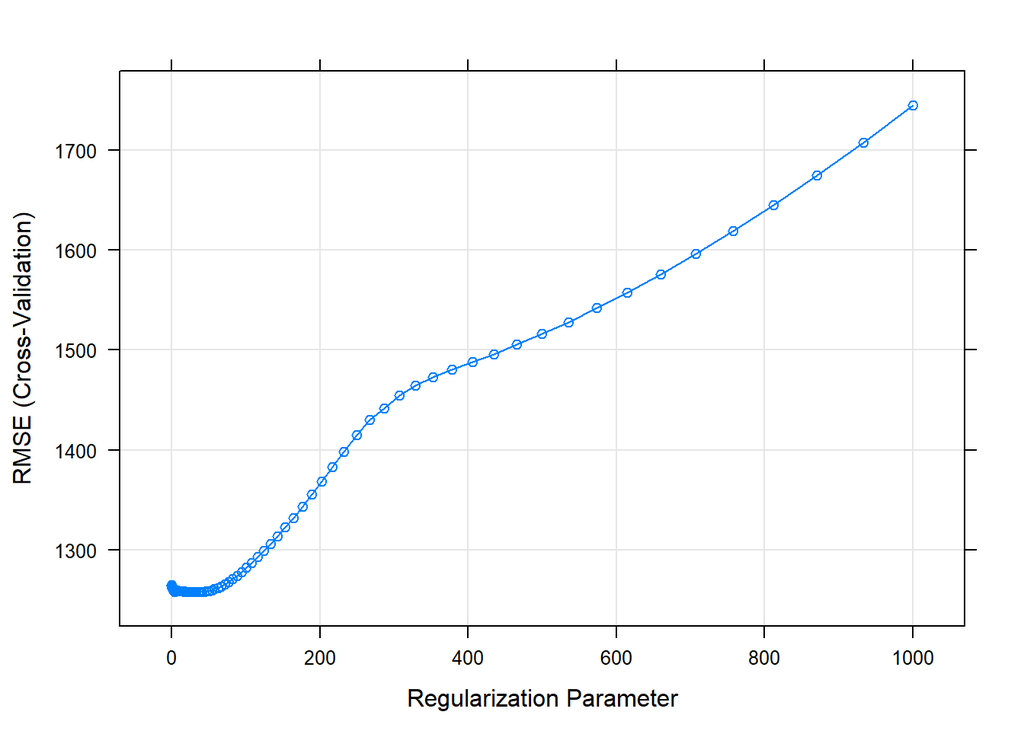

```r
lambda_seq <- c(0,10^seq(-3, 3, length = 200))

lasso1 <- train(total_count ~ . - date - total_casual - total_registered,
                data = train.bikedc, method = "glmnet",
                preProcess = "scale",
                trControl = trainControl("cv", number = 5),
                tuneGrid = expand.grid(alpha = 1,
                                   lambda = lambda_seq)
                )

plot(lasso1)
```

```r
lasso1$bestTune
```

```
##     alpha   lambda
## 152     1 33.31295
```

5. Using the previous results, show the model that lasso selected for prediction. How does it compare to the previous OLS model? Use the lasso model for prediction and estimate the RMSE. How does it compare to your previous OLS results?

**Answer:**

```r
coef(lasso1$finalModel, lasso1$bestTune$lambda)
```

```
## 13 x 1 sparse Matrix of class "dgCMatrix"
##                       1
## (Intercept)  2882.37083
## m_holiday       .
## m_workingday    .
## m_temp          .
## m_atemp      1164.56778
## m_humidity   -371.75639
## m_windspeed  -190.36517
## m_season2     365.87361
## m_season3      59.93588
## m_season4     556.25998
## m_weather2    -52.11149
## m_weather3   -280.40131
## m_weather4      .
```

```r
pred.count.lasso <- predict(lasso1, newdata = test.bikedc)

RMSE(pred.count.lasso, test.bikedc$total_count)
```

```
## [1] 1338.972
```

6. What would the advantages be of using a KNN approach compared to the OLS model we first fitted?

**Answer:** Nonparametric model (might help with bias)

7. Use bagging in combination with decision trees to get a final estimate of RMSE.
- What covariates are the most important? Which ones are the least important?
- Show your estimate of the RMSE.
- Why do you think the model that did better (according to your results) had better predictions than the others?

*Note: Only use 5 cross-validation folds and 15 bagged trees*

**Answer:**

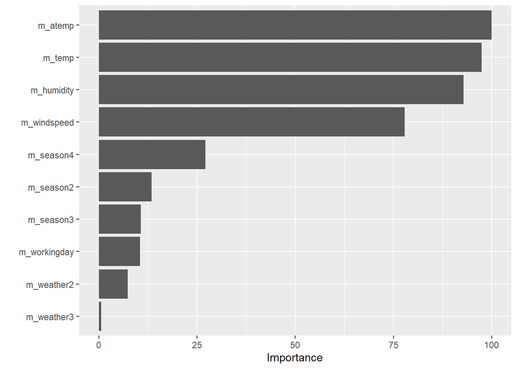

```r
library(rpart)

bt <- train(total_count ~ . - date - total_casual - total_registered, data = train.bikedc, method = "treebag",
            trControl = trainControl("cv", num = 5),
            nbagg = 15, control = rpart.control(cp = 0))


library(vip)

vip(bt)
```

```r
pred.count.bt <- predict(bt, newdata = test.bikedc)

RMSE(pred.count.bt, test.bikedc$total_count)
```

```
## [1] 1312.815
```

For this answer, you need to think about bias-variance. Talk about potential correlation of the covariates, how can model selection help that, why might bagging have problems with that, etc. Compare all three in their advantages and disadvantages, also using the **contextual information of your dataset** (remember that there’s not one method that outperforms all others, and usually depends on your data).

8. Do you think Random Forests would do better? Why? How would it compare to the previous bagging algorithm in terms of variance and bias?

**Answer:** Thing of the advantages (and differences) between RF and bagging. Talk about how RF solves some of the issues bagging might have, especially with this data (think about variable correlation).

## Causal Inference

Now assume we want to estimate the effect of certain interventions to incentivize the use of bike shares

1. Imagine that the intervention you had in mind was to reduce the price for causal riders and increase the price for registered riders. You are present in multiple cities in the US and you randomize this interventions at the city level.
- What would your outcome(s) of interest be?

**Answer:** Total rides, and total rides by type of customer.

- What would your estimand(s) of interest be? Explain it in terms of potential outcomes.

**Answer:** ATEs. Comparison between the rides that customers would have taken with the price change vs rides they would have taken without the price change.

2. What would be a check that you would run to ensure that randomization was done correctly?

**Answer:** Balance table of covariates. Talk about if you should expect some significant differences given the number of covariates you are testing.

Unfortunately, we did not get the approval to run an RCT, but we know that NYC experienced a similar change to the one we want to test in 2012.

3. What identification strategy would you use for this? Why do you think it would identify a causal estimate? What assumptions need to hold? Why could those assumptions fail? Give examples.

**Answer:** Diff-in-Diff. If both cities have similar trends over time, we could use this strategy, and there are no time-varying confounders.

4. Here is the daily data for bike share in NYC, under the same structure as `bikedc_daily`. Create a new variable called `nyc` for each dataframe (which should be 1 for NYC and 0 for DC), and append both datasets

*Note: you can extract the year of a date by using as.numeric(format(date, format=“%Y”))*

**Answer:**

```r
bikenyc_daily <- read.csv("https://raw.githubusercontent.com/maibennett/sta235/main/exampleSite/content/Classes/Week14/2_Wrapup/data/bikesharenyc_daily.csv")

bikenyc_daily <- bikenyc_daily %>% mutate(date = as.Date(date),
                                          m_season = factor(m_season),
                                          m_weather = factor(m_weather))

bike_daily <- bikenyc_daily %>% mutate(nyc=1) %>%
  add_row(bikedc_daily %>% mutate(nyc=0))

bike_daily <- bike_daily %>% mutate(year = as.numeric(format(date, format="%Y")),
                                    treat = ifelse(year==2012 & nyc==1,1,0))
```

5. Compare the (numeric) **weather covariates** for NYC and DC in 2011. Are these covariate balanced? Does this pose a problem for causal identification? Explain.

**Answer:**

```r
library(designmatch)

bike_daily_covs <- bike_daily %>% filter(year ==2011) %>% dplyr::select(-c(date,m_season, m_weather, total_casual, total_registered, total_count, year, treat, nyc, m_holiday, m_workingday))

meantab(bike_daily_covs, bike_daily$nyc[bike_daily$year==2011],which(bike_daily$nyc[bike_daily$year==2011]==1),which(bike_daily$nyc[bike_daily$year==2011]==0))
```

```
##             Mis  Min   Max Mean T Mean C Std Dif P-val
## m_temp        0 2.40 37.11  19.94  19.68    0.03  0.75
## m_atemp       0 3.99 37.88  19.69  23.08   -0.43  0.00
## m_humidity    0 0.00 97.04  63.41  63.41    0.00  1.00
## m_windspeed   0 1.50 36.42  15.98  12.93    0.58  0.00
```

6. Now you want to fit a differences-in-differences model for `total_count`, `total_casual`, and `total_registered`. What are the two-dimensions for DD here? Create any variable you might need, fit the model and explain your results. What conclusion can you make from these results?

**Answer:**

```r
bike_daily <- bike_daily %>% mutate(y2012 = factor(year==2012))

summary(lm(total_count ~ nyc + y2012 + nyc*y2012, data = bike_daily))
```

[output not shown]

```r
summary(lm(total_casual ~ nyc + y2012 + nyc*y2012, data = bike_daily))
```

```
##
## Call:
## lm(formula = total_casual ~ nyc + y2012 + nyc * y2012, data = bike_daily)
##
## Residuals:
##     Min      1Q  Median      3Q     Max
## -1169.7  -519.1  -104.0   214.8  2741.3
##
## Coefficients:
##               Estimate Std. Error t value Pr(>|t|)
## (Intercept)     683.41      47.55  14.372  < 2e-16 ***
## nyc             511.68      67.25   7.609 6.91e-14 ***
## y2012TRUE       353.07      67.25   5.250 1.89e-07 ***
## nyc:y2012TRUE   173.54      95.10   1.825   0.0684 .
## ---
## Signif. codes:  0 '***' 0.001 '**' 0.01 '*' 0.05 '.' 0.1 ' ' 1
##
## Residual standard error: 718 on 908 degrees of freedom
## Multiple R-squared:  0.214,  Adjusted R-squared:  0.2114
## F-statistic: 82.43 on 3 and 908 DF,  p-value: < 2.2e-16
```

```r
summary(lm(total_registered ~ nyc + y2012 + nyc*y2012, data = bike_daily))
```

```
##
## Call:
## lm(formula = total_registered ~ nyc + y2012 + nyc * y2012, data = bike_daily)
##
## Residuals:
##     Min      1Q  Median      3Q     Max
## -3224.6  -929.9   168.5   925.8  2240.3
##
## Coefficients:
##               Estimate Std. Error t value Pr(>|t|)
## (Intercept)    2746.32      76.49  35.904   <2e-16 ***
## nyc            1088.39     108.17  10.061   <2e-16 ***
## y2012TRUE      1934.29     108.17  17.881   <2e-16 ***
## nyc:y2012TRUE  -176.33     152.98  -1.153    0.249
## ---
## Signif. codes:  0 '***' 0.001 '**' 0.01 '*' 0.05 '.' 0.1 ' ' 1
##
## Residual standard error: 1155 on 908 degrees of freedom
## Multiple R-squared:  0.4539, Adjusted R-squared:  0.4521
## F-statistic: 251.6 on 3 and 908 DF,  p-value: < 2.2e-16
```

7. Make a plot for date and `total_count` for NYC and DC (in the same plot, different colors). Use `geom_smooth(method = "gam")` to help you out. Do you think that the parallel trend assumption holds? why or why not? Explain.

**Answer:**

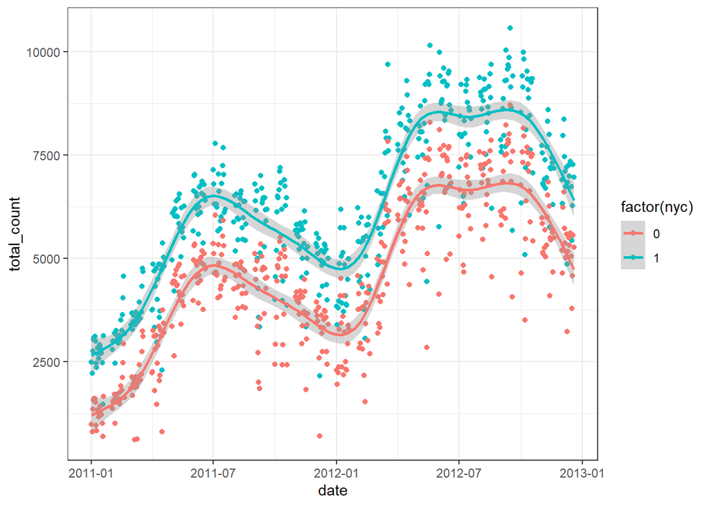

```r
library(ggplot2)

ggplot(data = bike_daily, aes(x = date, y = total_count, color = factor(nyc))) +
  geom_point() +
  geom_smooth(method = "gam") +
  theme_bw()
```

8. One of your co-workers comes with an analysis comparing New York data before and after, saying that the change was tremendously successful (run the code below). How would you respond to this? Use DC data to support your argument.

```r
summary(lm(total_count ~ y2012, data = bike_daily %>% filter(nyc==1)))
```

[output not shown]

**Answer:**

```r
summary(lm(total_count ~ y2012, data = bike_daily %>% filter(nyc==0)))
```

```
##
## Call:
## lm(formula = total_count ~ y2012, data = bike_daily %>% filter(nyc ==
##     0))
##
## Residuals:
##     Min      1Q  Median      3Q     Max
## -4188.1 -1170.5   271.9  1167.5  2996.9
##
## Coefficients:
##             Estimate Std. Error t value Pr(>|t|)
## (Intercept)  3429.73      97.92   35.03   <2e-16 ***
## y2012TRUE    2287.36     138.48   16.52   <2e-16 ***
## ---
## Signif. codes:  0 '***' 0.001 '**' 0.01 '*' 0.05 '.' 0.1 ' ' 1
##
## Residual standard error: 1479 on 454 degrees of freedom
## Multiple R-squared:  0.3754, Adjusted R-squared:  0.374
## F-statistic: 272.8 on 1 and 454 DF,  p-value: < 2.2e-16
```

9. Another co-worker laughs at the first one, saying that before-and-after is a ridiculous comparison, and that the real comparison that we should run for estimating the effect of the change is compare NYC and DC in the 2012. How would you respond to this? Use DC data to support your argument.

```r
summary(lm(total_count ~ nyc, data = bike_daily %>% filter(year==2012)))
```

[output not shown]

**Answer:**

```r
summary(lm(total_count ~ nyc, data = bike_daily %>% filter(year==2011)))
```

```
##
## Call:
## lm(formula = total_count ~ nyc, data = bike_daily %>% filter(year ==
##     2011))
##
## Residuals:
##     Min      1Q  Median      3Q     Max
## -3561.8 -1310.3   283.3  1168.5  2754.2
##
## Coefficients:
##             Estimate Std. Error t value Pr(>|t|)
## (Intercept)   3429.7       92.7   37.00   <2e-16 ***
## nyc           1600.1      131.1   12.21   <2e-16 ***
## ---
## Signif. codes:  0 '***' 0.001 '**' 0.01 '*' 0.05 '.' 0.1 ' ' 1
##
## Residual standard error: 1400 on 454 degrees of freedom
## Multiple R-squared:  0.2471, Adjusted R-squared:  0.2454
## F-statistic:   149 on 1 and 454 DF,  p-value: < 2.2e-16
```